# Lec24_1

```r
library(dplyr)
library(binom)
challenger <- read.csv("challenger.csv")
```

```r
## Aggregate data
w <- aggregate(O.ring ~ Temp, FUN = sum, data = challenger)
n <- aggregate(O.ring ~ Temp +Number, FUN = length, data = challenger)

#Each row has 6 obs, so multiply each length by 6 to get number of Trials.
n %>% mutate(Trials = Number*O.ring) %>% select(-Number, -O.ring) -> n

# Output
aggdat <- data.frame(O.ring = w$O.ring, Temp = w$Temp, Trials = n$Trials)
aggdat %>% mutate(Proportion = round(O.ring/Trials, 2)) -> aggdat
print(aggdat)
```

```
##    O.ring Temp Trials Proportion
## 1       2   53      6       0.33
## 2       1   57      6       0.17
## 3       1   58      6       0.17
## 4       1   63      6       0.17
## 5       0   66      6       0.00
## 6       0   67     18       0.00
## 7       0   68      6       0.00
## 8       0   69      6       0.00
## 9       2   70     24       0.08
## 10      0   72      6       0.00
## 11      0   73      6       0.00
## 12      2   75     12       0.17
## 13      0   76     12       0.00
## 14      0   78      6       0.00
## 15      0   79      6       0.00
## 16      0   81      6       0.00
```

```r
fit <- glm(O.ring/Trials ~ Temp, weights = Trials, family = binomial(link = "logit"), data = aggdat)
summary(fit) -> i

## Deviance residuals
i$deviance.resid
```

```
##            1            2            3            4            5
##  0.394196272 -0.097108964  0.009530722  0.502571817 -0.952269177
##            6            7            8            9           10
## -1.559891368 -0.851563415 -0.805041863  0.759187198 -0.679531979
##           11           12           13           14           15
## -0.642034715  2.045364521 -0.765334235 -0.482697309 -0.455828277
##           16
## -0.406427154
```

Most of the residuals float around 0, but there is 1 residual that is >2.

One out of 16 is somewhere around 5%, so I do not concern too much about this rare residual, but it still worths check out.

```r
s.res <- rstandard(fit, type = "pearson")
aggdat %>% mutate(Std.Peason = round(s.res, 2)) -> aggdat
aggdat
```

```
##    O.ring Temp Trials Proportion Std.Peason
## 1       2   53      6       0.33       0.56
## 2       1   57      6       0.17      -0.11
## 3       1   58      6       0.17       0.01
## 4       1   63      6       0.17       0.57
## 5       0   66      6       0.00      -0.71
## 6       0   67     18       0.00      -1.22
## 7       0   68      6       0.00      -0.63
## 8       0   69      6       0.00      -0.59
## 9       2   70     24       0.08       0.94
## 10      0   72      6       0.00      -0.50
## 11      0   73      6       0.00      -0.47
## 12      2   75     12       0.17       3.18
## 13      0   76     12       0.00      -0.58
## 14      0   78      6       0.00      -0.35
## 15      0   79      6       0.00      -0.33
## 16      0   81      6       0.00      -0.30
```

At Temp=75 the standard Pearson residual is 3.18, notice this is the same observation that has large deviance residual.

```r
## Make data for plotting
pi.hat <- predict(fit, type = "response")
lin.pred <- fit$linear.predictors
p.res <- residuals(fit, type = "pearson")
bin <- data.frame(aggdat, pi.hat, s.res, p.res, lin.pred)
bin <- round(bin,2)
bin
```

```
##    O.ring Temp Trials Proportion Std.Peason pi.hat s.res p.res lin.pred
## 1       2   53      6       0.33       0.56   0.26  0.56  0.40    -1.04
## 2       1   57      6       0.17      -0.11   0.18 -0.11 -0.10    -1.50
## 3       1   58      6       0.17       0.01   0.17  0.01  0.01    -1.62
## 4       1   63      6       0.17       0.57   0.10  0.57  0.54    -2.20
## 5       0   66      6       0.00      -0.71   0.07 -0.71 -0.69    -2.54
## 6       0   67     18       0.00      -1.22   0.07 -1.22 -1.12    -2.66
## 7       0   68      6       0.00      -0.63   0.06 -0.63 -0.61    -2.78
## 8       0   69      6       0.00      -0.59   0.05 -0.59 -0.58    -2.89
## 9       2   70     24       0.08       0.94   0.05  0.94  0.84    -3.01
## 10      0   72      6       0.00      -0.50   0.04 -0.50 -0.49    -3.24
## 11      0   73      6       0.00      -0.47   0.03 -0.47 -0.46    -3.35
## 12      2   75     12       0.17       3.18   0.03  3.18  2.99    -3.59
## 13      0   76     12       0.00      -0.58   0.02 -0.58 -0.54    -3.70
## 14      0   78      6       0.00      -0.35   0.02 -0.35 -0.34    -3.93
## 15      0   79      6       0.00      -0.33   0.02 -0.33 -0.32    -4.05
## 16      0   81      6       0.00      -0.30   0.01 -0.30 -0.29    -4.28
```

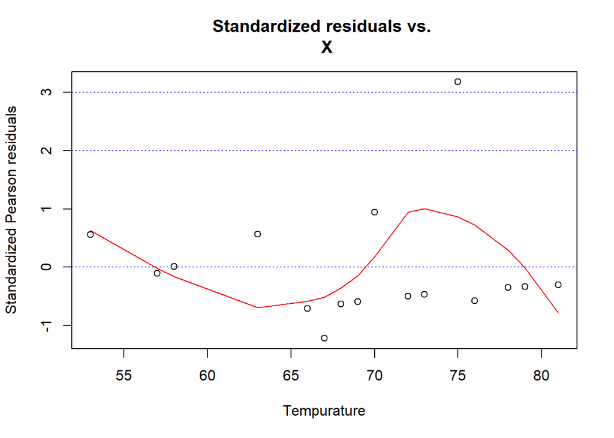

```r
# Standardized Pearson residual vs X plot
plot(x = bin$Temp, y = bin$s.res, xlab = "Tempurature", ylab = "Standardized Pearson residuals",
     main = "Standardized residuals vs. \n X")
abline(h = c(3, 2, 0, -2, -3), lty = "dotted", col = "blue")
smooth.stand <- loess(formula = s.res ~ Temp, weights = Trials, data = bin )
order.dist <- order(bin$Temp)
lines(x = bin$Temp[order.dist], y = predict(smooth.stand)[order.dist], lty = "solid", col = "red", lwd = 1)
```

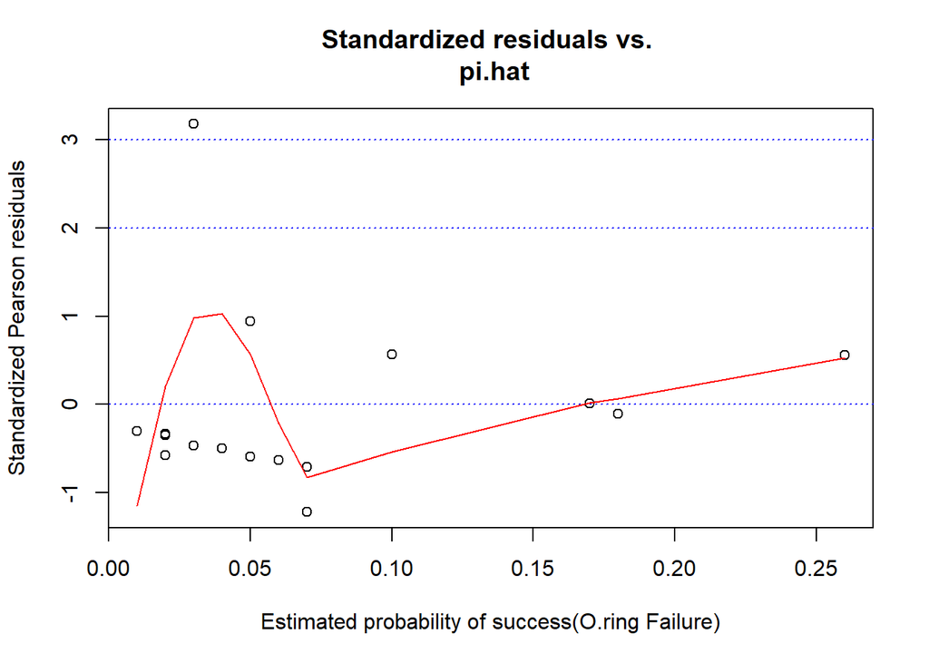

```r
# Standardized Pearson residual vs pi plot
plot(x = bin$pi.hat, y = bin$s.res, xlab = "Estimated probability of success(O.ring Failure)", ylab = "Standardized Pearson residuals", main = "Standardized residuals vs. \n pi.hat")
abline(h = c(3, 2, 0, -2, -3), lty = "dotted", col = "blue")
smooth.stand <- loess(formula = s.res ~ pi.hat, data = bin, weights = Trials)
order.pi.hat <- order(bin$pi.hat)
lines(x = bin$pi.hat[order.pi.hat], y = predict(smooth.stand)[order.pi.hat], lty = "solid", col = "red", lwd = 1)
```

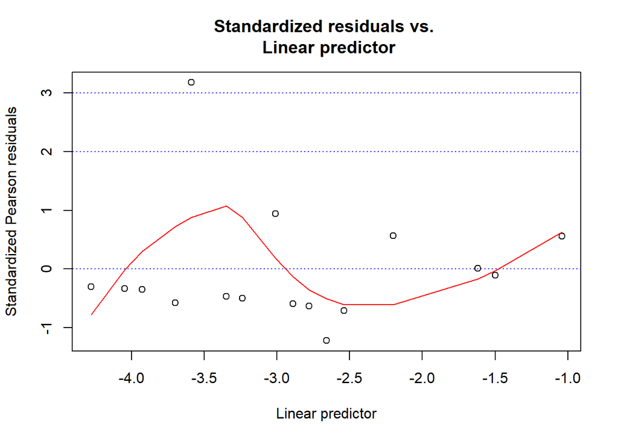

```r
# Standardized Pearson residual vs linear predictor plot
plot(x = bin$lin.pred, y = bin$s.res, xlab = "Linear predictor", ylab = "Standardized Pearson residuals",
     main = "Standardized residuals vs. \n Linear predictor")
abline(h = c(3, 2, 0, -2, -3), lty = "dotted", col = "blue")
smooth.stand <- loess(formula = s.res ~ lin.pred, data = bin, weights = Trials)
order.lin.pred <- order(bin$lin.pred)
lines(x = bin$lin.pred[order.lin.pred], y = predict(smooth.stand)[order.lin.pred], lty = "solid", col = "red", lwd = 1)
```

1. All 3 plots appears to have curvature, but the residuals mostly stay around 0.
2. Variance seems not constant around low probabilities, when probability goes higher variance seems a little more constant.
3. There is one observation with residual greater than 3, we can see the curves have been “dragged” to fit this extreme point. I consider this happens because of discrete data, beacause this extreme point appears at near pi=0. At small pi the variance is also small, therefore a rare success will inflate the residual.

Overall: the model fit seems not bad

Due to the discreteness of data, we cannot get much information from the extreme residual, but other than that, a lot of estimates seem to have slightly negative residual, so we may need to modify the model.